# Análise de sentimentos das reclamações de órgãos do governo federal

9 de novembro de 2018

### Importando dados para um dataframe

```r
avaliacao_humana = read_csv("../data/3-avaliacao-humana/avaliacoes-20181030.csv")
reclamacoes = read_csv("../data/3-avaliacao-humana/reclamacoes-avaliadas-20180703.csv")
```

### Análise exploratória: etapa 1

A partir desse momento, iremos explorar um pouco das reclamações selecionadas.

#### A quantidade de caracteres em uma reclamação muda de um órgão federal para o outro?

A princípio é necessário calcular a quantidade de caracteres de cada reclamação e posteriormente adicionar o dado comprimento ao dataframe.

```r
reclamacoes <- reclamacoes %>%
    mutate(comprimento = str_length(reclamacao))
```

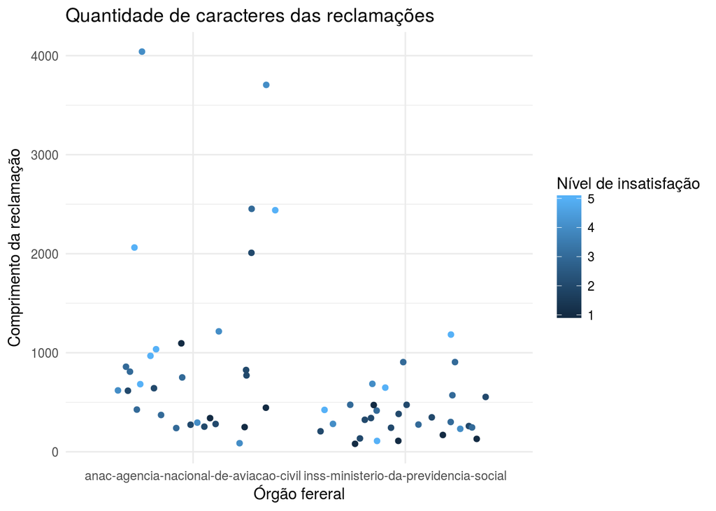

```r
reclamacoes %>%
  mutate(`Nível de insatisfação` = insatisfacao) %>%
  ggplot(aes(x = orgao,
             y = comprimento,
             color = `Nível de insatisfação`)) +
  geom_jitter() +
  labs(title = "Quantidade de caracteres das reclamações",
       x = "Órgão fereral",
       y = "Comprimento da reclamação")
```

Como podemos ver no gráfico acima, o ANAC teve reclamações com número maior de caracteres e também com um nível maior de insatisfação. Já o INSS, teve uma maior homogeniedade de caracteres, só uma reclamação passou dos 1000 caracteres e com nota 5 insatisfação. A partir dessas conclusões podemos ver que reclamações que tiveram maior número de caracteres tambḿe teve maior número de grau de insatisfação.

Uma forma comum de se demostrar insatisfação por meio da escrita digital é adicionar pontos de exclamação e letras maiúsculas.

#### A partir do comentário acima, seria válido fazer a verificação de letras maiúsculas em cada reclamação e sinais de pontuação como a exclamação(!)

Assim como a visualizaação anterior, precisamos contabilizar a quantidade de letras maiúsculas e pontos de exclamação:

```r
reclamacoes$numero_de_capslock <- str_count(reclamacoes$reclamacao,"\\b[A-Z]{2,}\\b")
reclamacoes$numero_de_exclamacoes <- str_count(reclamacoes$reclamacao, "!")
```

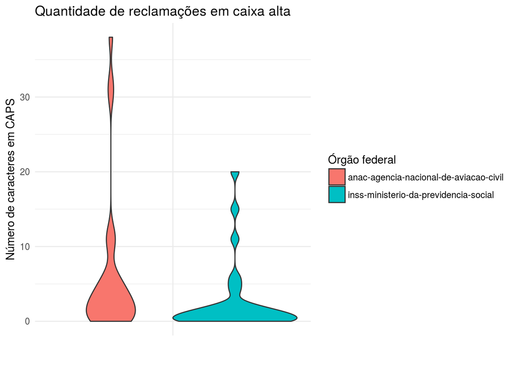

```r
reclamacoes %>%
  mutate(`Órgão federal` = orgao) %>%
  ggplot(aes(y = numero_de_capslock,
             x = "",
             fill = `Órgão federal`)) +
  geom_violin() +
  labs(title = "Quantidade de reclamações em caixa alta",
       x = "",
       y = "Número de caracteres em CAPS")
```

Como podemos observar, a ANAC tem um número considerável de reclamações com caracteres em caixa alta, inclusive reclamações que ultrapassam a quantidade de 30 caracteres em caps. Já o INSS, tem uma presença menor de caracteres em caps em suas reclamações, inclusive com uma grande concentração de reclamações com caixa alta abaixo de 10 caracteres, um bom número, contando que início de frase comece com letra maiúscula, presença de nomes próprios, etc.

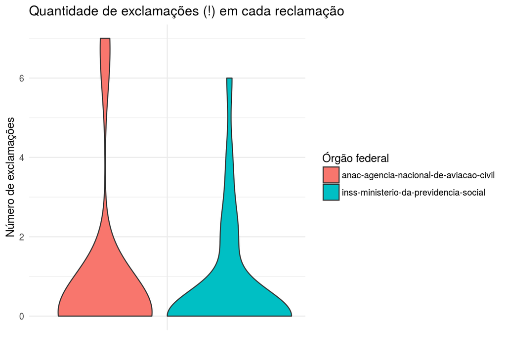

```r
reclamacoes %>%
  mutate(`Órgão federal` = orgao) %>%
  ggplot(aes(y = numero_de_exclamacoes,
             x = "",
             fill = `Órgão federal`)) +
  geom_violin() +
  labs(title = "Quantidade de exclamações (!) em cada reclamação",
       x = "",
       y = "Número de exclamações")
```

Já para o número de exclamações, temos o seguinte cenário: o INSS tem uma maior concentração desse caractere, no entanto o ANAC, tem algumas reclamações com uma presença de mais de 6 exclamações.

### Análise exploratória: etapa 2

Nesta etapa preparamos questionamentos para a análise das avaliações humanas para as reclamações.

A princípio, uma breve sumarização dos dados contidos nos resultados da avaliação humana:

```r
avaliacao_humana %>%
    group_by(`ID da reclamação`) %>%
    arrange(`ID da reclamação`) %>%
    summarise(media_reclamacao = mean(`Grau de insatisfação`),
              mediana_reclamacao = median(`Grau de insatisfação`),
              desvio = sd(`Grau de insatisfação`))
```

[output not shown]

[output cut: 51 more lines]

Além disso, podemos também responder outra pergunta acerca dos dados.

#### Dessa maneira, podemos dizer que pessoas que receberam a mesma reclamação classificaram igualmente?

```r
distribuicao_avaliacao <- function(filtro) {
    result <- avaliacao_humana %>%
        filter(`ID da reclamação` %in% filtro) %>%

        ggplot(aes(x = reorder(`ID da reclamação`, `ID da reclamação`),
                   y = `Grau de insatisfação`,
                   color = Matrícula)) +
        geom_boxplot(outlier.colour = NA) +
        geom_jitter(width = .2, alpha = .5, height = 0.05) +
        labs(title = "Distribuição de notas por reclamação",
             x = "Id da reclamação")

    return(result)
}
```

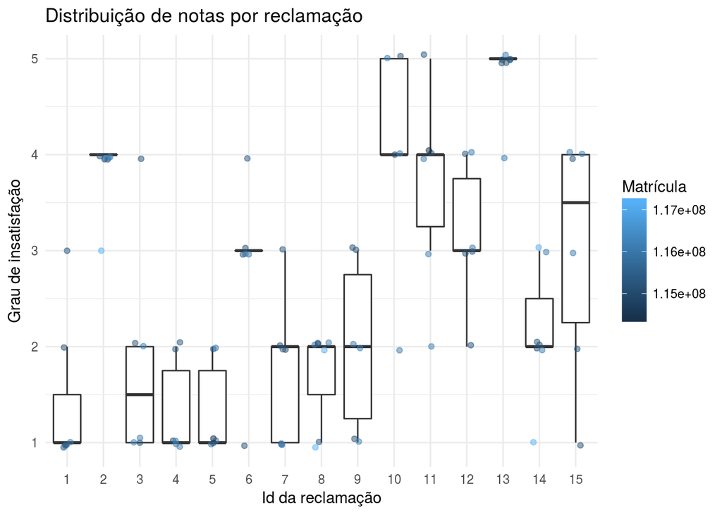

```r
distribuicao_avaliacao(1:15)
```

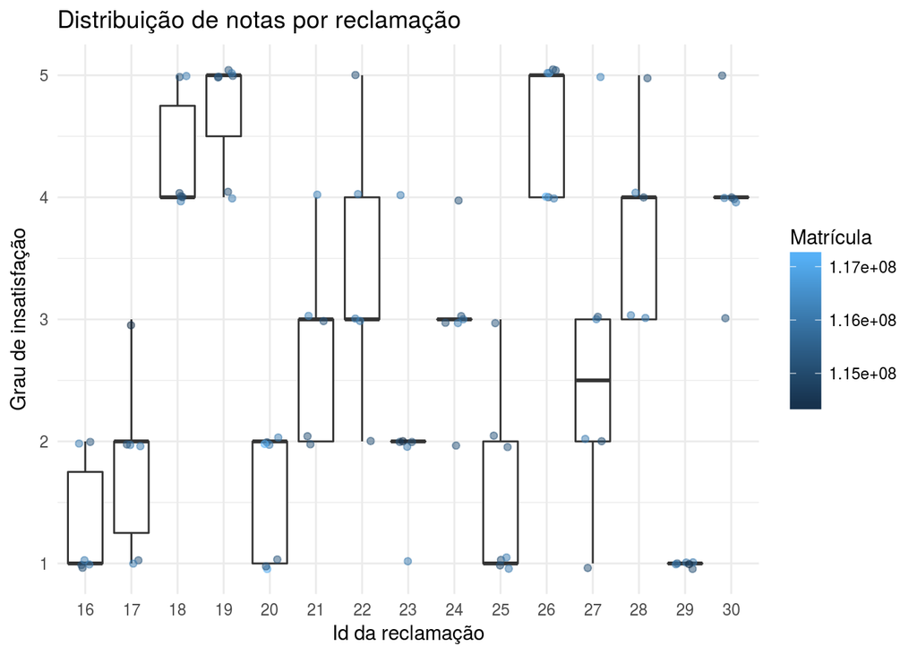

```r
distribuicao_avaliacao(16:30)
```

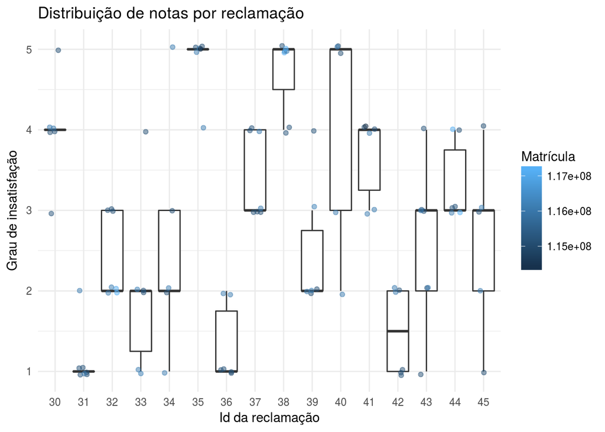

```r
distribuicao_avaliacao(30:45)
```

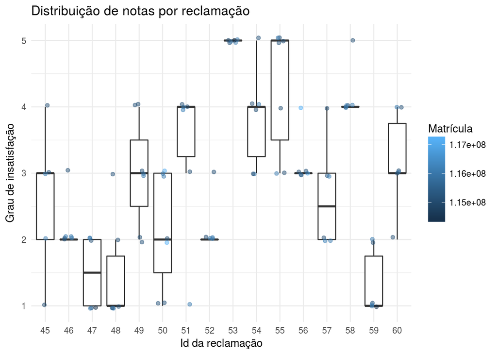

```r
distribuicao_avaliacao(45:60)
```